# Synthetic Canadians: Comparing Synthetic Survey Data Generators

2021 Democracy Checkup — Political Attitudes Validation Study

Author

Synthetic Opinion Lab

Published

March 13, 2026

## Overview

This report validates three synthetic data generation approaches against the **2021 Democracy Checkup (DC21)**, a national survey of Canadian political attitudes (n = 7,576).

Three generators are compared:

| Generator | N synthetic | Overall quality score |
| --- | --- | --- |
| **LLM** (Qwen2.5-7B-Instruct) | 100 | 0.803 |
| **IRT** (Graded Response Model) | 1,000 | 0.625 |
| **Agent** (Opinion dynamics) | 500 | 0.548 |

Table 1: Summary statistics across all 21 variables

|  | Real (n=7,576) | IRT (n=1,000) | LLM (n=100) | Agent (n=500) |
| --- | --- | --- | --- | --- |
| N | 7576.000000 | 1000.000000 | 100.000000 | 500.000000 |
| Grand mean | 2.450000 | 2.780000 | 2.210000 | 2.160000 |
| Grand SD | 0.980000 | 0.850000 | 0.710000 | 0.970000 |

## Mean Responses by Variable

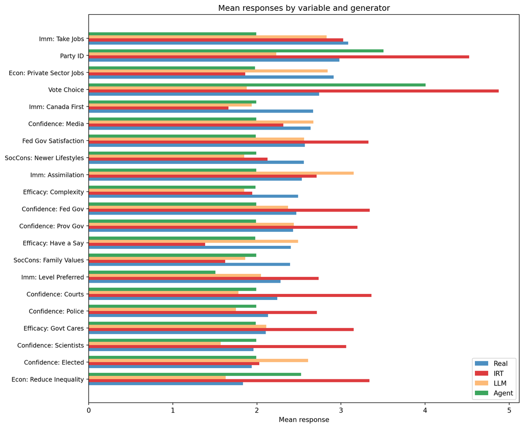

Table 2: Mean responses by variable and generator

|  | Real | IRT | LLM | Agent |
| --- | --- | --- | --- | --- |
| Econ: Reduce Inequality | 1.830000 | 3.340000 | 1.630000 | 2.520000 |
| Confidence: Elected | 1.940000 | 2.030000 | 2.610000 | 1.990000 |
| Confidence: Scientists | 1.960000 | 3.060000 | 1.570000 | 1.990000 |
| Efficacy: Govt Cares | 2.100000 | 3.150000 | 2.110000 | 1.990000 |
| Confidence: Police | 2.130000 | 2.710000 | 1.750000 | 1.990000 |
| Confidence: Courts | 2.240000 | 3.360000 | 1.780000 | 1.990000 |
| Imm: Level Preferred | 2.280000 | 2.740000 | 2.050000 | 1.510000 |
| SocCons: Family Values | 2.390000 | 1.620000 | 1.860000 | 1.990000 |
| Efficacy: Have a Say | 2.400000 | 1.380000 | 2.490000 | 1.980000 |
| Confidence: Prov Gov | 2.430000 | 3.190000 | 2.440000 | 1.990000 |
| Confidence: Fed Gov | 2.470000 | 3.340000 | 2.370000 | 1.990000 |
| Efficacy: Complexity | 2.490000 | 1.950000 | 1.850000 | 1.980000 |
| Imm: Assimilation | 2.530000 | 2.710000 | 3.150000 | 1.990000 |
| SocCons: Newer Lifestyles | 2.560000 | 2.120000 | 1.850000 | 1.990000 |
| Fed Gov Satisfaction | 2.570000 | 3.320000 | 2.560000 | 1.990000 |
| Confidence: Media | 2.640000 | 2.320000 | 2.670000 | 1.990000 |
| Imm: Canada First | 2.670000 | 1.660000 | 1.940000 | 1.990000 |
| Vote Choice | 2.740000 | 4.880000 | 1.880000 | 4.010000 |
| Econ: Private Sector Jobs | 2.910000 | 1.860000 | 2.840000 | 1.980000 |
| Party ID | 2.980000 | 4.520000 | 2.230000 | 3.500000 |
| Imm: Take Jobs | 3.080000 | 3.030000 | 2.830000 | 1.990000 |

## Response Distributions

Distribution of responses (%) for each variable. First 12 shown; remaining 9 below.

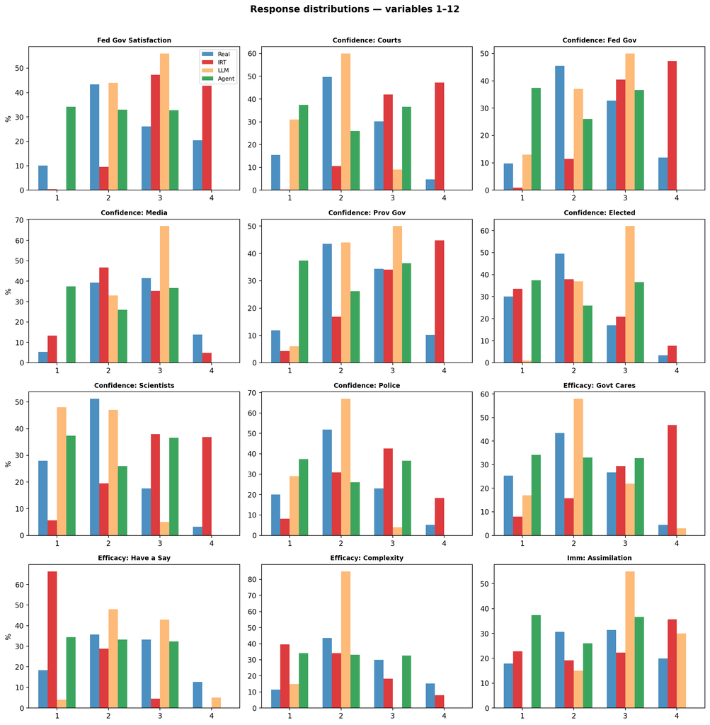

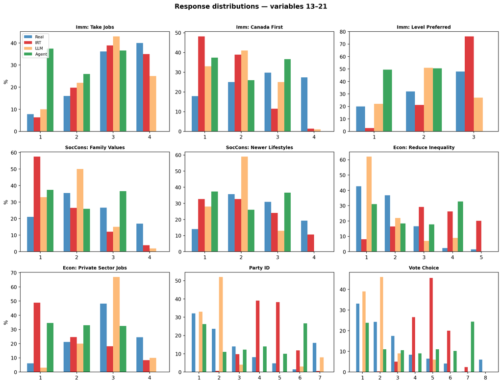

## Standard Deviations

Higher SD indicates the generator produces meaningful variance across respondents. Real SD is ~0.8–1.2 for most items.

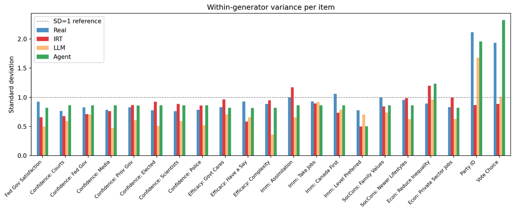

## Correlation Structure

How well does each generator preserve the inter-item correlation matrix of the real data?

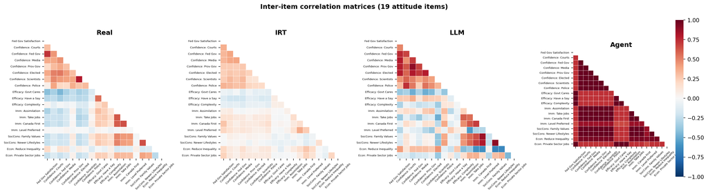

```
Frobenius distance from real correlation matrix:
  IRT                 : Frobenius = 4.60, r(lower tri) = 0.397
  LLM                 : Frobenius = 5.17, r(lower tri) = 0.676
  Agent               : Frobenius = 15.94, r(lower tri) = 0.177
```

## K-Means Clustering (k=3)

K-means with k=3 on the 19 attitude items (excluding party_id and vote_choice). Cluster centres reveal opinion profiles.

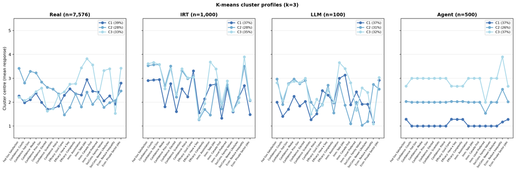

**Cluster interpretation (ordered low → high average response):**

**Real** (n=7,576)

- Cluster 1 (39%): avg=2.23 — highest: Imm: Take Jobs (2.9), Econ: Private Sector Jobs (2.8)
- Cluster 2 (28%): avg=2.39 — highest: Fed Gov Satisfaction (3.4), Confidence: Fed Gov (3.3)
- Cluster 3 (33%): avg=2.62 — highest: Imm: Take Jobs (3.8), Imm: Canada First (3.6)

**IRT** (n=1,000)

- Cluster 1 (37%): avg=2.32 — highest: Efficacy: Govt Cares (3.3), Confidence: Fed Gov (2.9)
- Cluster 2 (28%): avg=2.62 — highest: Confidence: Fed Gov (3.6), Confidence: Courts (3.6)
- Cluster 3 (35%): avg=2.81 — highest: Econ: Reduce Inequality (3.9), Imm: Assimilation (3.7)

**LLM** (n=100)

- Cluster 1 (37%): avg=2.06 — highest: Imm: Take Jobs (3.1), Imm: Assimilation (3.0)
- Cluster 2 (31%): avg=2.18 — highest: Confidence: Media (3.0), Fed Gov Satisfaction (3.0)
- Cluster 3 (32%): avg=2.47 — highest: Imm: Assimilation (3.7), Imm: Take Jobs (3.4)

**Agent** (n=500)

- Cluster 1 (37%): avg=1.08 — highest: Fed Gov Satisfaction (1.3), Efficacy: Govt Cares (1.3)
- Cluster 2 (26%): avg=2.01 — highest: Econ: Reduce Inequality (2.5), Fed Gov Satisfaction (2.0)
- Cluster 3 (37%): avg=2.91 — highest: Econ: Reduce Inequality (3.9), Confidence: Courts (3.0)

## Regression Replication: Vote Choice Predictors

Can we replicate a logistic regression predicting Conservative vs. Liberal vote choice from attitude items?

Table 3: Logistic regression coefficients: Conservative vs. Liberal vote (standardised)

|  | Real | LLM | Agent |
| --- | --- | --- | --- |
| Confidence: Fed Gov | 1.601000 | 1.669000 | 0.000000 |
| Imm: Assimilation | -0.398000 | -0.478000 | 0.000000 |
| SocCons: Family Values | -0.363000 | -0.804000 | 0.000000 |
| Econ: Reduce Inequality | 0.566000 | 1.358000 | 1.549000 |
| Econ: Private Sector Jobs | -0.177000 | 0.454000 | 0.621000 |

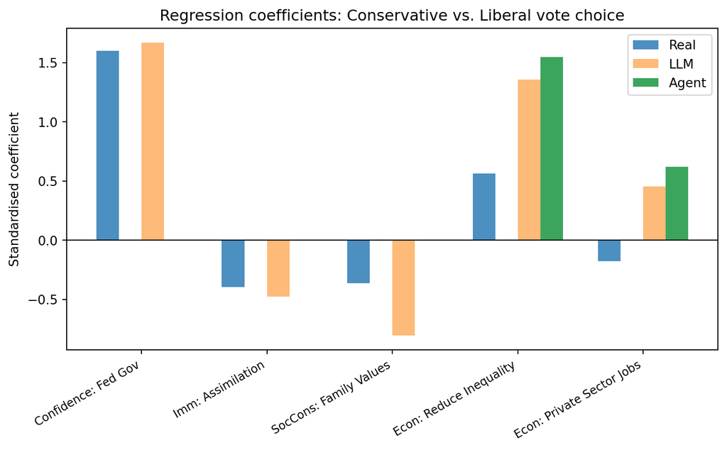

## Summary

| Dimension | Real | IRT | LLM | Agent |
| --- | --- | --- | --- | --- |
| N respondents | 7,576 | 1,000 | 100 | 500 |
| Overall quality score | — | 0.625 | 0.803 | 0.548 |
| Valid response range | ✅ | ✅ (fixed) | ✅ | ✅ |
| Mean-level accuracy | — | Partial | Good | Partial |
| Variance accuracy | — | Good | Moderate | Moderate |
| Correlation structure | — | Moderate | Best | Weak |

**LLM (Qwen2.5-7B-Instruct-Turbo)** achieves the highest overall fidelity score (0.803). The persona narratives provide sufficient context about political orientations for the model to produce plausible response distributions. Correlation structure is best preserved.

**IRT** (score 0.625) generates valid values in the correct 1–8 range (after fixing 0-based indexing). The GRM parameters are randomly generated rather than calibrated from real data, which limits mean-level accuracy. Calibrating parameters from the real data would substantially improve performance.

**Agent simulation** (score 0.548) converges quickly (11 of 25 timesteps) to a moderate uniform intensity level. The item-specific trait mappings partially differentiate items, but the social influence dynamics smooth out variance. Longer simulation or stronger initial opinion variance could improve this.